# Calculation of Timothy and Watergrass seed abundance for summer 2020

Emilio A. Laca

2021-02-14

## 0.1 Names of variables

Whenever a different name is encountered for these variables, it will be corrected accordingly.

1. Refuge (for spelled-out refuge names, do not use as a key field)
2. LIT (use as the key field)
3. Unit_Name
4. Subunit_Name
5. subunit_ID (paste(LIT, Unit_Name, Subunit_Name, sep = "_"))
6. group (paste(LIT, Unit_Name, Subunit_Name, Stratum, sep = "_"))
7. Stratum (“a.Low”, “b.Med”, “c.High”)
8. LIT_Strat (factor(paste(LIT, Stratum, sep = "_")))

## 0.2 Read RDS’s

## 0.3 Models to go from seed dimensions to mass

## 0.4 Prepare utility info

## 0.5 Read data files

```
## 'data.frame':    350 obs. of  10 variables:
##  $ LIT           : chr  "KRN" "KRN" "KRN" "KRN" ...
##  $ Unit_Name     : chr  "4A" "4A" "4A" "4A" ...
##  $ Subunit_Name  : chr  "4A-1" "4A-1" "4A-1" "4A-1" ...
##  $ Stratum       : Factor w/ 3 levels "a.Low","b.Med",..: 1 1 1 2 3 3 1 1 2 3 ...
##  $ avg_length_mm : num  8.2 8 6.4 12.6 10.4 8 11.2 11.8 11.8 12.2 ...
##  $ n_seed_head_m2: num  2222.2 8400 44.4 2133.3 18800 ...
##  $ no_sh         : num  2222.2 8400 44.4 2133.3 18800 ...
##  $ mass_g_m2     : num  24.65 89.546 0.306 52.532 327.417 ...
##  $ subunit_ID    : chr  "KRN_4A_4A-1" "KRN_4A_4A-1" "KRN_4A_4A-1" "KRN_4A_4A-1" ...
##  $ LIT_Strat     : Factor w/ 12 levels "KRN_a.Low","KRN_b.Med",..: 1 1 1 2 3 3 1 1 2 3 ...
```

```
## 'data.frame':    125 obs. of  10 variables:
##  $ LIT           : chr  "MDC" "MDC" "MDC" "MDC" ...
##  $ Unit_Name     : chr  "Gadwall" "Gadwall" "Grandma Tract 10" "Grandma Tract 10" ...
##  $ Subunit_Name  : chr  "Gadwall" "Gadwall" "Grandma Tract 10" "Grandma Tract 10" ...
##  $ Stratum       : Factor w/ 3 levels "a.Low","b.Med",..: 1 2 1 1 2 2 1 1 1 2 ...
##  $ avg_length_mm : num  48 67 43.2 25.6 20.4 ...
##  $ n_seed_head_m2: num  40 50 70 80 220 320 30 10 100 60 ...
##  $ sh_mass_mg    : num  37.9 63.1 40.1 22.5 16.5 ...
##  $ mass_g_m2     : num  1.51 3.15 2.81 1.8 3.62 ...
##  $ subunit_ID    : chr  "MDC_Gadwall_Gadwall" "MDC_Gadwall_Gadwall" "MDC_Grandma Tract 10_Grandma Tract 10" "MDC_Grandma Tract 10_Grandma Tract 10" ...
##  $ LIT_Strat     : Factor w/ 8 levels "MDC_a.Low","MDC_b.Med",..: 1 2 1 1 2 2 1 1 1 2 ...
```

## 0.6 Area per subunit

## 0.7 Estimation of proportions of areas

Proportion of areas

See http://www.analyticalgroup.com/download/WEIGHTED_MEAN.pdf for var(weighted average) and AREA FRAME DESIGN.pdf

## 0.8 Function to estimate mass per unit area in each stratum

```
##      Stratum
## LIT   a.Low b.Med c.High
##   MDC    46    22     25
##   PIX    16     6      6
##   SLW     3     0      1
```

Make a data frame with the seed mass per unit area for each stratum, and species (columns) for each subunit (rows). `seed_mass_fun` is a function that takes the file `p_Area`, and the models for g.m2 by Subunit_Name and Stratum (“st_rlm3” and “wg_rlm3”) as arguments and yields the seed mass of st and wg per unit area of each subunit, and the area of each subunit. The resulting file can be used to calculate refuge-level yields.

## 0.9 Mass per subunit and refuge

### 0.9.1 Mass per subunit is given as average g/m2 over the whole subunit area.

```
## tibble [65 × 14] (S3: tbl_df/tbl/data.frame)
##  $ LIT           : chr [1:65] "KRN" "KRN" "KRN" "KRN" ...
##  $ Unit_Name     : chr [1:65] "4A" "4A" "4A" "4A" ...
##  $ Subunit_Name  : chr [1:65] "4A-1" "4A-2" "4A-3" "4A-4" ...
##  $ subunit_ID    : chr [1:65] "KRN_4A_4A-1" "KRN_4A_4A-2" "KRN_4A_4A-3" "KRN_4A_4A-4" ...
##  $ st_g_m2_a.Low : num [1:65] 32.9 32.9 32.9 32.9 32.9 ...
##  $ st_g_m2_b.Med : num [1:65] 118 118 118 118 118 ...
##  $ st_g_m2_c.High: num [1:65] 300 300 300 300 300 ...
##  $ wg_g_m2_a.Low : num [1:65] 0 0 0 0 0 0 0 0 0 0 ...
##  $ wg_g_m2_b.Med : num [1:65] 0 0 0 0 0 0 0 0 0 0 ...
##  $ wg_g_m2_c.High: num [1:65] 0 0 0 0 0 0 0 0 0 0 ...
##  $ wg_g_m2       : num [1:65] 0 0 0 0 0 0 0 0 0 0 ...
##  $ st_g_m2       : num [1:65] 74 83.9 265.9 143 181.5 ...
##  $ tot_g_m2      : num [1:65] 74 83.9 265.9 143 181.5 ...
##  $ area_ha       : num [1:65] 19.48 17.46 8.98 20.62 21.95 ...
##  - attr(*, "na.action")= 'omit' Named int [1:18] 66 67 68 69 70 71 72 73 74 75 ...
##   ..- attr(*, "names")= chr [1:18] "66" "67" "68" "69" ...
##  - attr(*, "notes")= chr "These estimations exclude the uncertainty due to the proportion of area covered by each stratum in each unit, a"| __truncated__
```

Average seed mass per subunit area. Total mass of seed estimated for the subunit divided by the total area of the subunit. These estimations exclude the uncertainty due to the proportion of area covered by each stratum in each unit, and the uncertainty of the model to convert seed number and seed length into mass.

| LIT | Unit_Name | Subunit_Name | wg_g_m2 | st_g_m2 | tot_g_m2 | area_ha |
| --- | --- | --- | --- | --- | --- | --- |
| KRN | 4A | 4A-1 | 0.0 | 74.0 | 74.0 | 19.5 |
| KRN | 4A | 4A-2 | 0.0 | 83.9 | 83.9 | 17.5 |
| KRN | 4A | 4A-3 | 0.0 | 265.9 | 265.9 | 9.0 |
| KRN | 4A | 4A-4 | 0.0 | 143.0 | 143.0 | 20.6 |
| KRN | 4A | 4A-5 | 0.0 | 181.5 | 181.5 | 22.0 |
| KRN | 4A | 4A-6 | 0.0 | 86.5 | 86.5 | 26.7 |
| KRN | 4B | 4B-1 | 0.0 | 99.8 | 99.8 | 25.9 |
| KRN | 4B | 4B-2 | 0.0 | 71.9 | 71.9 | 17.7 |
| KRN | 4B | 4B-3 | 0.0 | 249.8 | 249.8 | 19.0 |
| KRN | 5A | 5A-1 | 0.0 | 156.2 | 156.2 | 18.7 |
| KRN | 5A | 5A-3 | 0.0 | 63.2 | 63.2 | 21.2 |
| KRN | 5A | 5A-4 | 0.0 | 104.5 | 104.5 | 18.9 |
| KRN | 5A | 5A-6 | 0.0 | 172.2 | 172.2 | 14.1 |
| KRN | 5A | 5A-7 | 0.0 | 112.1 | 112.1 | 19.6 |
| KRN | 5B | 5B-1 | 0.0 | 149.6 | 149.6 | 9.2 |
| KRN | 5B | 5B-2 | 0.0 | 61.3 | 61.3 | 11.9 |
| KRN | 5B | 5B-3 | 0.0 | 110.0 | 110.0 | 23.3 |
| KRN | 5B | 5B-5 | 0.0 | 24.3 | 24.3 | 20.3 |
| KRN | 5B | 5B-6 | 0.0 | 92.5 | 92.5 | 13.0 |
| KRN | 5B | 5B-7 | 0.0 | 198.8 | 198.8 | 12.1 |
| KRN | 5B | 5B-8 | 0.0 | 122.0 | 122.0 | 19.4 |
| KRN | 6A | 6A-1 | 0.0 | 69.4 | 69.4 | 21.8 |
| KRN | 6A | 6A-2 | 0.0 | 48.0 | 48.0 | 20.2 |
| KRN | 6A | 6A-4 | 0.0 | 83.6 | 83.6 | 11.5 |
| KRN | 6A | 6A-5 | 0.0 | 95.9 | 95.9 | 13.8 |
| MDC | Duck Ponds | Duck Ponds | 0.0 | 130.3 | 130.3 | 71.7 |
| MDC | Flournoy Pond | Flournoy Pond | 0.0 | 73.7 | 73.7 | 21.7 |
| MDC | Gadwall | Gadwall | 0.2 | 46.5 | 46.7 | 26.0 |
| MDC | Grandma Tract 10 | Grandma Tract 10 | 0.2 | 0.0 | 0.2 | 14.0 |
| MDC | Grandma Tract 11 | Grandma Tract 11 | 0.0 | 0.0 | 0.0 | 6.1 |
| MDC | Grandma Tract 2 | Grandma Tract 2 | 1.7 | 17.5 | 19.2 | 8.5 |
| MDC | Grandma Tract 3 | Grandma Tract 3 | 6.8 | 0.0 | 6.8 | 12.5 |
| MDC | Grandma Tract 4 | Grandma Tract 4 | 1.0 | 0.0 | 1.0 | 11.9 |
| MDC | Grandma Tract 7 | Grandma Tract 7 | 0.0 | 0.0 | 0.0 | 14.3 |
| MDC | Grandma Tract 8 | Grandma Tract 8 | 0.6 | 0.0 | 0.6 | 11.2 |
| MDC | Grandma Tract 9 | Grandma Tract 9 | 0.9 | 0.0 | 0.9 | 11.2 |
| MDC | House Field | House Field | 0.0 | 130.0 | 130.0 | 25.4 |
| MDC | J Pond | J Pond | 3.9 | 8.8 | 12.8 | 22.8 |
| MDC | Matney 3 | Matney 3 | 0.0 | 74.9 | 74.9 | 12.0 |
| MDC | Matney 4 North | Matney 4 North | 0.8 | 77.1 | 77.9 | 8.3 |
| MDC | Matney 4 South | Matney 4 South | 1.7 | 54.2 | 56.0 | 7.6 |
| MDC | Matney 6 | Matney 6 | 0.5 | 83.2 | 83.7 | 9.4 |
| MDC | Matney 7 | Matney 7 | 0.0 | 0.0 | 0.0 | 10.1 |
| MDC | Matney 8 | Matney 8 | 6.0 | 18.0 | 24.0 | 12.6 |
| MDC | South Dam Pond | South Dam Pond | 0.0 | 58.5 | 58.5 | 8.5 |
| MDC | Upper Goose Pond | Upper Goose Pond | 0.0 | 100.3 | 100.3 | 21.2 |
| PIX | 1 | 1 | 0.0 | 69.1 | 69.1 | 57.1 |
| PIX | 2 | 2 | 1.9 | 267.4 | 269.4 | 20.1 |
| PIX | 2A | 2A | 0.2 | 182.5 | 182.7 | 22.4 |
| PIX | 3 | 3 | 9.5 | 250.0 | 259.5 | 19.6 |
| PIX | 3A | 3A | 7.6 | 237.9 | 245.5 | 30.0 |
| PIX | 4 | 4 | 6.0 | 202.3 | 208.2 | 18.1 |
| PIX | 4A | 4A | 1.5 | 97.7 | 99.2 | 18.3 |
| PIX | 6 | 6 | 0.0 | 52.6 | 52.6 | 46.3 |
| PIX | 7A | 7A | 0.0 | 252.7 | 252.7 | 12.7 |
| PIX | 7B | 7B | 143.8 | 9.0 | 152.8 | 12.2 |
| PIX | 8A | 8A | 0.0 | 93.2 | 93.2 | 11.6 |
| PIX | 8B | 8B | 0.5 | 261.8 | 262.2 | 17.8 |
| PIX | 9A | 9A | 9.0 | 233.6 | 242.6 | 12.4 |
| PIX | 9B | 9B | 1.1 | 227.8 | 228.9 | 13.5 |
| SLW | Beach Lake 1 | Beach Lake 1 | 0.0 | 9.6 | 9.6 | 16.5 |
| SLW | Beach Lake 3 | Beach Lake 3 | 0.0 | 89.9 | 89.9 | 7.3 |
| SLW | Lewis 1 | 22 | 2.5 | 14.3 | 16.8 | 12.0 |
| SLW | Lewis 6 | 22 | 7.5 | 8.5 | 16.0 | 23.7 |
| SLW | LIC | 57 | 1.3 | 81.6 | 82.8 | 28.7 |

### 0.9.2 Calculate mass per refuge (kg) based on original sample.

Total seed mass in each refuge, areas and seed mass per unit area. These estimations exclude the uncertainty due to the proportion of area covered by each stratum in each unit, and the uncertainty of the model to convert seed number and seed length into mass.

| LIT | mass_kg_lit | tot_ha | kg.ha |
| --- | --- | --- | --- |
| KRN | 499015 | 447 | 1117 |
| MDC | 217252 | 347 | 626 |
| PIX | 508144 | 312 | 1629 |
| SLW | 37720 | 88 | 428 |

## 0.10 Mass estimates and distributions with quadrat variance.

Seed yield, confidence intervals. etc. for each subunit and refuge are calculated by resampling yield per stratum for each subunit.

Using `tidymodels` and `rsample`.

```
##    user  system elapsed
## 105.334   0.618 106.394
```

```
## # A tibble: 65 x 10
##    subunit_ID  wg_q10 wg_mean  wg_q90  st_q10 st_mean  st_q90 tot_q10 tot_mean
##    <chr>        <dbl>   <dbl>   <dbl>   <dbl>   <dbl>   <dbl>   <dbl>    <dbl>
##  1 KRN_4A_4A… 0.      0.      0.      6.94e+1 7.39e+1 7.85e+1  69.4     73.9
##  2 KRN_4A_4A… 0.      0.      0.      7.84e+1 8.38e+1 8.96e+1  78.4     83.8
##  3 KRN_4A_4A… 0.      0.      0.      2.47e+2 2.66e+2 2.85e+2 247.     266.
##  4 KRN_4A_4A… 0.      0.      0.      1.34e+2 1.43e+2 1.52e+2 134.     143.
##  5 KRN_4A_4A… 0.      0.      0.      1.69e+2 1.81e+2 1.94e+2 169.     181.
##  6 KRN_4A_4A… 0.      0.      0.      8.13e+1 8.64e+1 9.15e+1  81.3     86.4
##  7 KRN_4B_4B… 0.      0.      0.      9.38e+1 9.97e+1 1.06e+2  93.8     99.7
##  8 KRN_4B_4B… 0.      0.      0.      6.74e+1 7.18e+1 7.61e+1  67.4     71.8
##  9 KRN_4B_4B… 0.      0.      0.      2.34e+2 2.50e+2 2.66e+2 234.     250.
## 10 KRN_5A_5A… 0.      0.      0.      1.47e+2 1.56e+2 1.66e+2 147.     156.
## 11 KRN_5A_5A… 0.      0.      0.      5.92e+1 6.32e+1 6.73e+1  59.2     63.2
## 12 KRN_5A_5A… 0.      0.      0.      9.78e+1 1.04e+2 1.11e+2  97.8    104.
```

[output cut: 54 more lines]

## 0.11 Mass estimates with quadrat and area variance

### 0.11.1 Sum of products of independent variables

This approach is approximate because it assumes that composition variables are independent, but it includes the correction for finite population.

The formula used is:

$$\sigma^2_{\sum(X_i Y_i)} = \sum{\left((\sigma^2_{X_i} + \mu^2_{X_i})(\sigma^2_{Y_i} + \mu^2_{Y_i}) - \mu^2_{X_i} \mu^2_{Y_i}\right)}$$

where $X_i$ are the values of mass per unit are for each stratum and the $Y_i$ are the proportions of each stratum in the subunit. The variances of $X_i$ are obtained from the bootstrapped data and the variances of $Y_i$ are given by the calculation of `v_Area_c`.

```
## # A tibble: 65 x 9
##    LIT   Unit_Name Subunit_Name wg_g_m2 st_g_m2  CI80lwr tot_g_m2 CI80upr
##    <chr> <chr>     <chr>          <dbl>   <dbl>    <dbl>    <dbl>   <dbl>
##  1 KRN   5A        5A-1         0.      1.56e+2 140.      156.    172.
##  2 KRN   6A        6A-4         0.      8.36e+1  74.8      83.6    92.3
##  3 KRN   5B        5B-7         0.      1.99e+2 176.      199.    221.
##  4 KRN   4B        4B-1         0.      9.98e+1  88.2      99.8   111.
##  5 KRN   5A        5A-6         0.      1.72e+2 152.      172.    192.
##  6 PIX   9B        9B           1.10e+0 2.28e+2 201.      229.    256.
##  7 KRN   4A        4A-4         0.      1.43e+2 125.      143.    161.
##  8 KRN   4B        4B-3         0.      2.50e+2 218.      250.    282.
##  9 KRN   6A        6A-5         0.      9.59e+1  83.8      95.9   108.
## 10 PIX   4         4            5.96e+0 2.02e+2 181.      208.    236.
## 11 PIX   8B        8B           4.50e-1 2.62e+2 229.      262.    296.
## 12 PIX   2A        2A           1.72e-1 1.82e+2 157.      183.    208.
```

[output cut: 54 more lines]

## 0.12 Graphical display of results =======

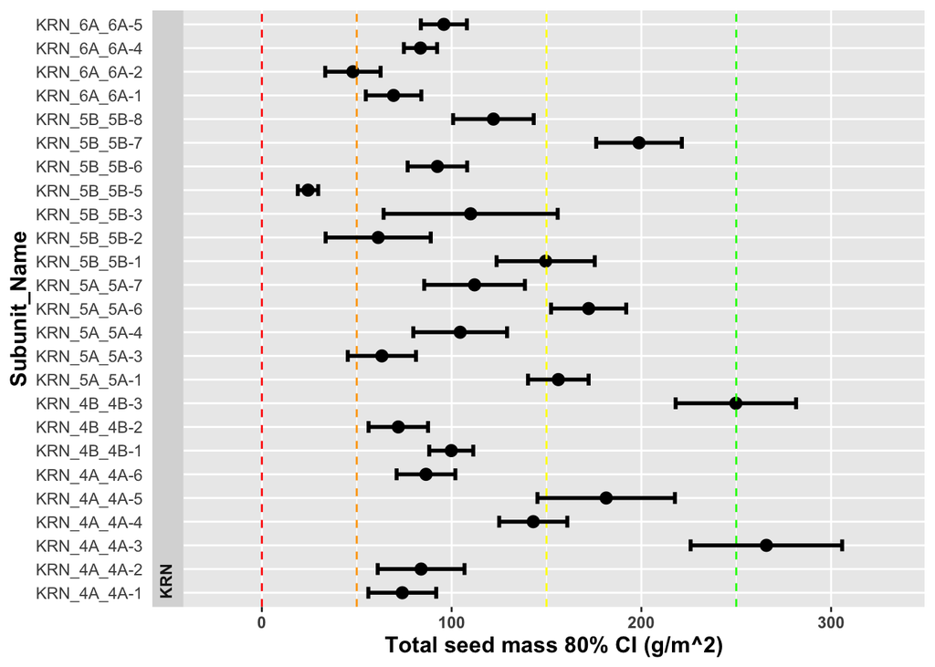

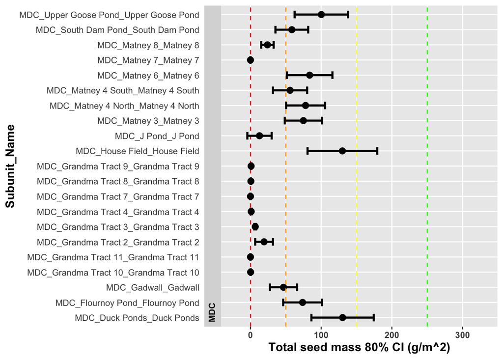

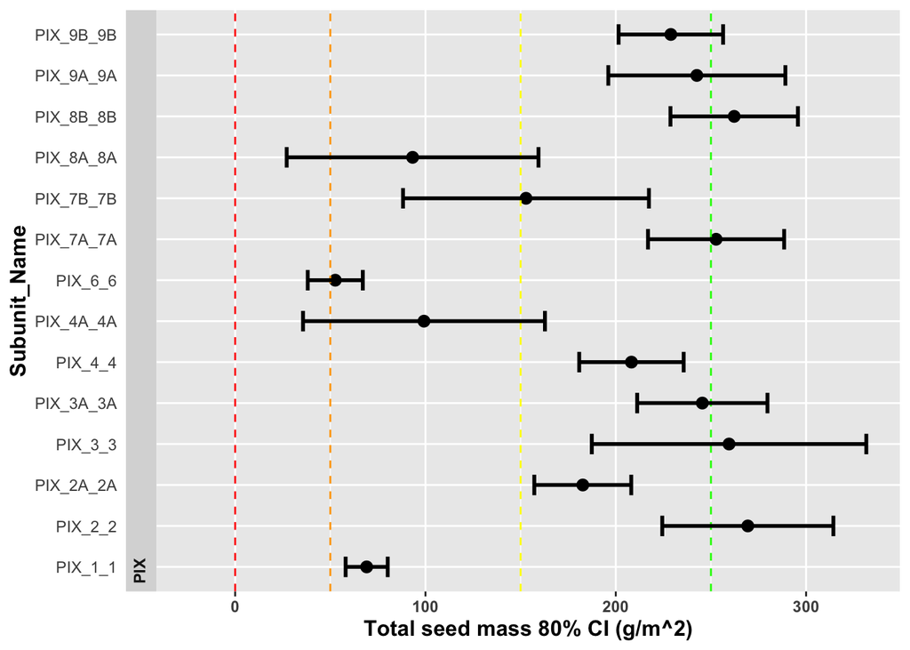

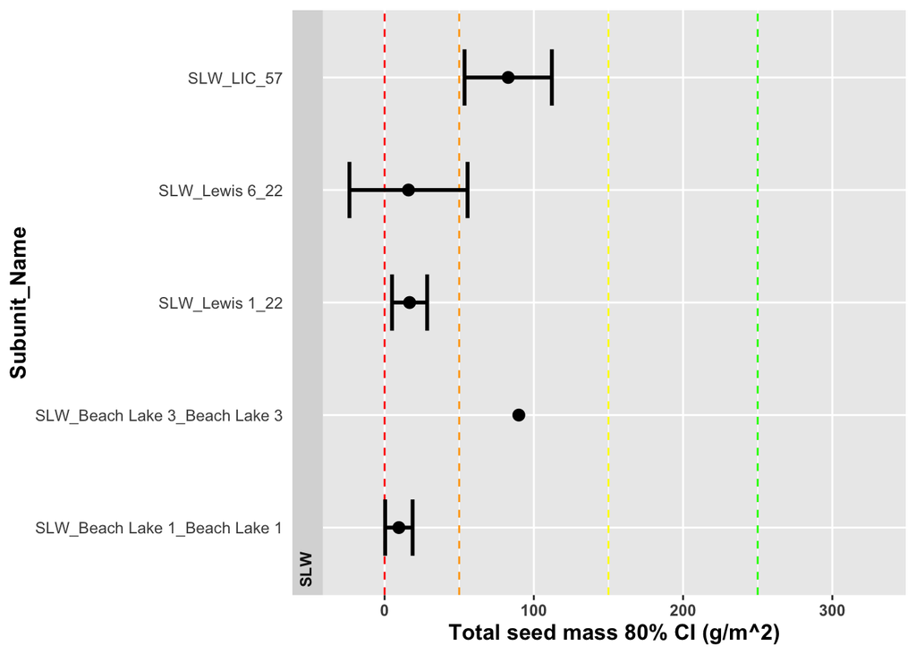

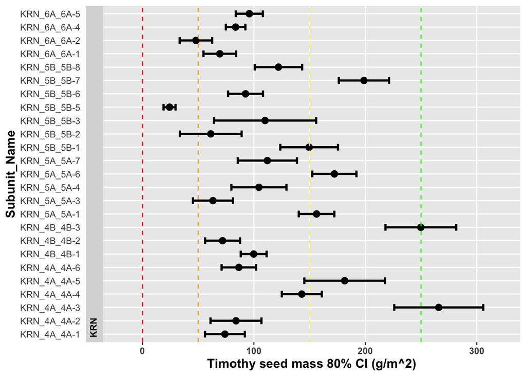

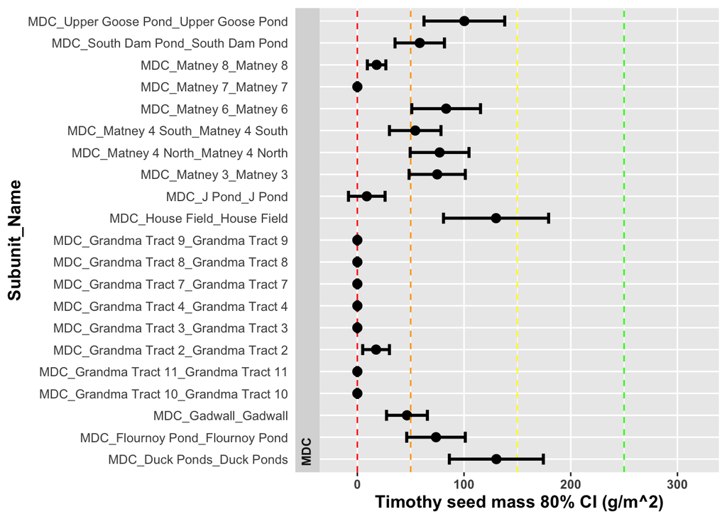

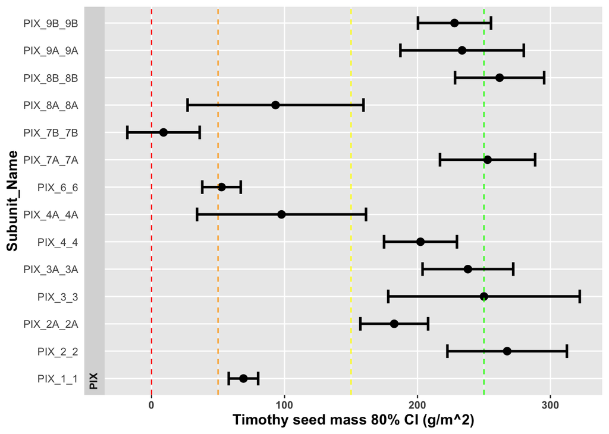

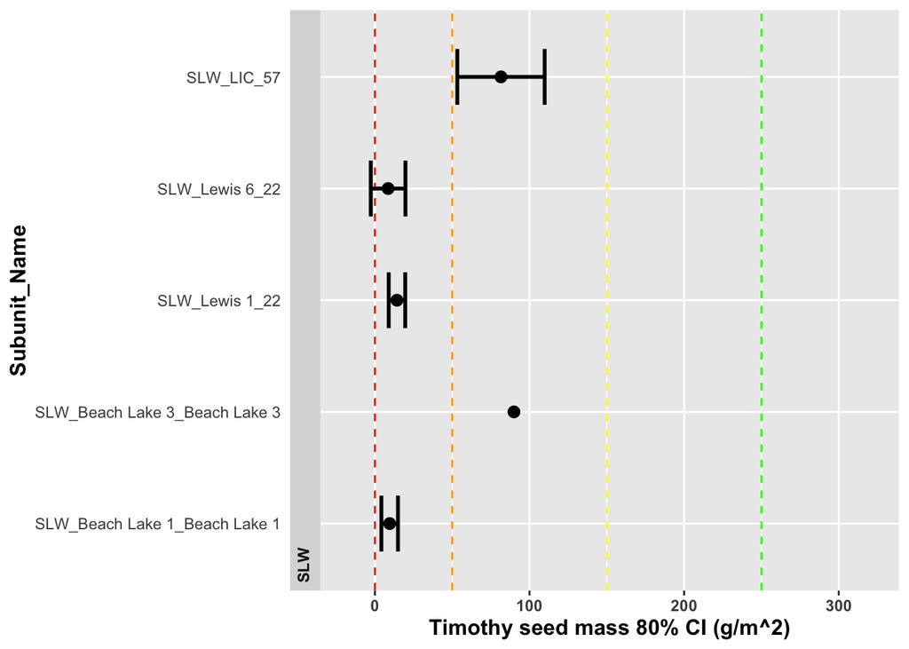

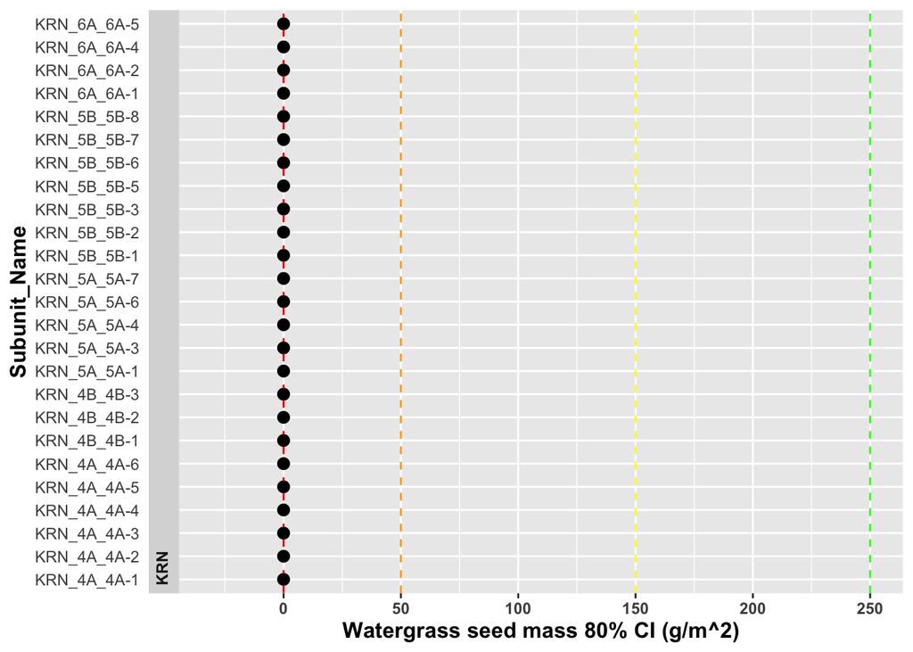

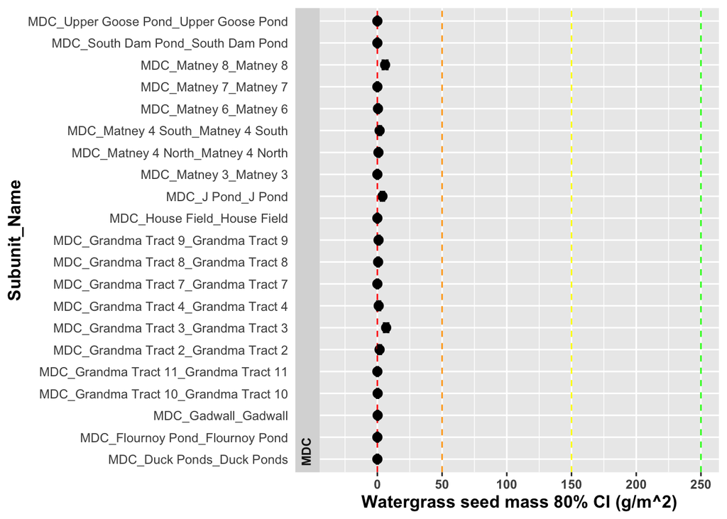

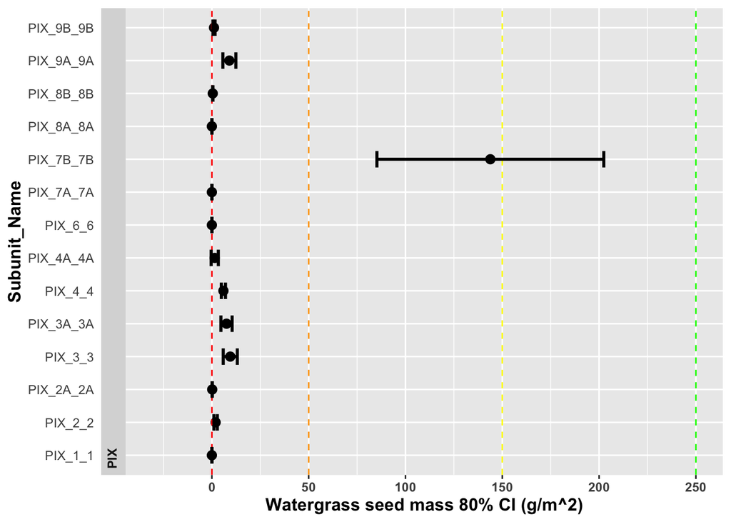

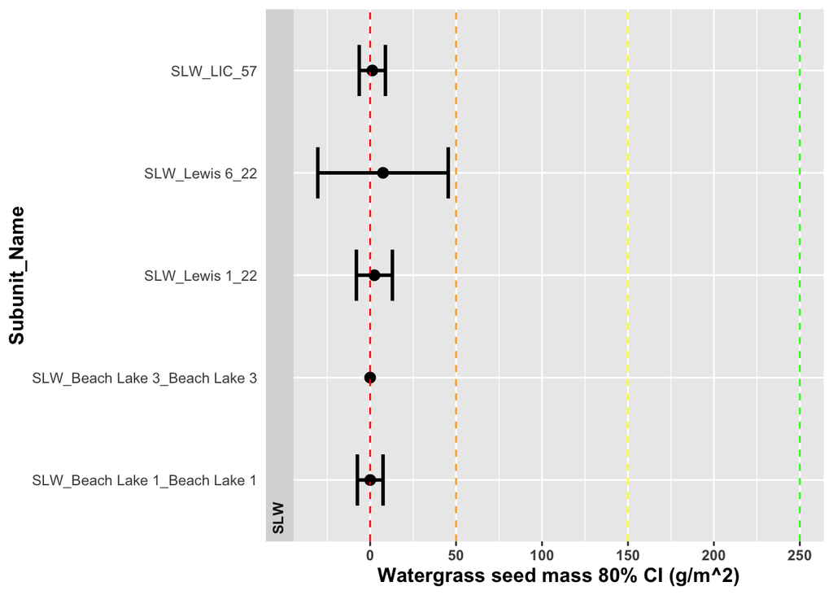

## 0.13 Test of differences in mass/m.sq among units within refuge

```
## # A tibble: 300 x 4
##     diff.name                   mean.a mean.b approx_p_value
##     <chr>                        <dbl>  <dbl>          <dbl>
##   1 KRN_4A_4A-2 vs. KRN_4A_4A-1   83.9   74.0    0.331
##   2 KRN_4A_4A-3 vs. KRN_4A_4A-1  266.    74.0    0.00000001
##   3 KRN_4A_4A-4 vs. KRN_4A_4A-1  143.    74.0    0.000241
##   4 KRN_4A_4A-5 vs. KRN_4A_4A-1  181.    74.0    0.000326
##   5 KRN_4A_4A-6 vs. KRN_4A_4A-1   86.5   74.0    0.249
##   6 KRN_4B_4B-1 vs. KRN_4A_4A-1   99.8   74.0    0.0603
##   7 KRN_4B_4B-2 vs. KRN_4A_4A-1   71.9   74.0    0.455
##   8 KRN_4B_4B-3 vs. KRN_4A_4A-1  250.    74.0    0
##   9 KRN_5A_5A-1 vs. KRN_4A_4A-1  156.    74.0    0.00000552
##  10 KRN_5A_5A-3 vs. KRN_4A_4A-1   63.2   74.0    0.293
##  11 KRN_5A_5A-4 vs. KRN_4A_4A-1  105.    74.0    0.0999
##  12 KRN_5A_5A-6 vs. KRN_4A_4A-1  172.    74.0    0.00000120
```

[output cut: 608 more lines]

```
## [1] "Proportion of area in each stratum by subunit"
```

```
## # A tibble: 65 x 8
##    subunit_ID p_wg_a.Low p_wg_b.Med p_wg_c.High p_st_a.Low p_st_b.Med
##    <chr>           <dbl>      <dbl>       <dbl>      <dbl>      <dbl>
##  1 KRN_4A_4A…  0           0            0         0.253       0.0789
##  2 KRN_4A_4A…  0.0367      0            0.312     0.0940      0.0324
##  3 KRN_4A_4A…  0           0            0         0           0
##  4 KRN_4A_4A…  0           0            0         0.200       0.151
##  5 KRN_4A_4A…  0           0            0         0.137       0.0605
##  6 KRN_4A_4A…  0           0            0         0.168       0.169
##  7 KRN_4B_4B…  0           0            0         0.183       0.134
##  8 KRN_4B_4B…  0           0            0         0.0816      0.212
##  9 KRN_4B_4B…  0           0            0         0           0.216
## 10 KRN_5A_5A…  0           0            0         0.197       0.322
## 11 KRN_5A_5A…  0           0            0         0.0788      0.0504
## 12 KRN_5A_5A…  0           0            0         0.113       0.0552
```

[output cut: 54 more lines]

```
## [1] "Mean seed mass per area for Timothy"
```

```
##  LIT_Strat  emmean   SE df asymp.LCL asymp.UCL
##  KRN_a.Low   32.93 12.0 NA      9.36      56.5
##  KRN_b.Med  117.65 14.7 NA     88.79     146.5
##  KRN_c.High 299.52 11.8 NA    276.36     322.7
##  MDC_a.Low    4.72 24.3 NA    -42.84      52.3
##  MDC_b.Med  112.84 19.8 NA     74.01     151.7
##  MDC_c.High 156.91 13.8 NA    129.78     184.0
##  PIX_a.Low   44.91 21.4 NA      2.97      86.9
##  PIX_b.Med   96.86 19.8 NA     58.03     135.7
##  PIX_c.High 343.54 14.7 NA    314.67     372.4
##  SLW_a.Low   24.35 26.2 NA    -27.02      75.7
##  SLW_b.Med   59.28 26.2 NA      7.91     110.6
##  SLW_c.High 244.04 22.0 NA    200.88     287.2
##
## Confidence level used: 0.95
```

```
## [1] "Mean seed mass per area for Watergrass"
```

```
##  LIT_Strat   emmean    SE df asymp.LCL asymp.UCL
##  MDC_a.Low    0.986 0.393 NA     0.216      1.76
##  MDC_b.Med    2.956 0.568 NA     1.842      4.07
##  MDC_c.High   7.658 0.533 NA     6.613      8.70
##  PIX_a.Low   24.602 0.666 NA    23.296     25.91
##  PIX_b.Med   51.724 1.088 NA    49.592     53.86
##  PIX_c.High 168.125 1.088 NA   165.993    170.26
##  SLW_a.Low   12.590 1.539 NA     9.575     15.61
##  SLW_c.High  13.443 2.665 NA     8.220     18.67
##
## Confidence level used: 0.95
```